# Final

```python
import pandas as pd
import seaborn as sns
import matplotlib.pyplot as plt
from sklearn.preprocessing import LabelEncoder
from sklearn.model_selection import train_test_split
from sklearn.ensemble import RandomForestClassifier
from sklearn.model_selection import GridSearchCV
from sklearn.preprocessing import OneHotEncoder
from sklearn.compose import ColumnTransformer
from sklearn.pipeline import Pipeline
```

```python
df = pd.read_csv('accident_data_updated.csv')
```

```python
# Tính tỷ lệ NaN trong cột Road_Type
nan_ratio = df['Road_Type'].isna().mean() * 100
print(f"Tỷ lệ NaN trong cột Road_Type là: {nan_ratio:.2f}%")
```

```
Tỷ lệ NaN trong cột Road_Type là: 0.68%
```

#### Xóa những dòng có giá trị bằng NaN hoặc là Other trong cột để đễ dàng hơn trong quá trình phân tích

```python
# Thay 'Other' thành NaN và xóa các dòng chứa NaN
df.replace('Other', pd.NA, inplace=True)
df.dropna(inplace=True)
```

```python
statistics = df.describe()

# In ra bảng thống kê
print(statistics)
```

```
       Number_of_Casualties  Number_of_Vehicles
count         625797.000000        625797.00000
mean               1.360459             1.83436
std                0.827672             0.71661
min                1.000000             1.00000
25%                1.000000             1.00000
50%                1.000000             2.00000
75%                1.000000             2.00000
max               68.000000            32.00000
```

```python
# Xóa những dòng có giá trị là 'Unknown' trong tất cả các cột
df_cleaned = df[~df.isin(['Unknown']).any(axis=1)]
```

```python
df_cleaned = df[~df.isin(['Other']).any(axis=1)]
```

```python
df_cleaned.head(10)
```

|  | Index | Accident_Severity | Accident Date | Light_Conditions | District Area | Number_of_Casualties | Number_of_Vehicles | Road_Surface_Conditions | Road_Type | Urban_or_Rural_Area | Weather_Conditions | Vehicle_Type |
| --- | --- | --- | --- | --- | --- | --- | --- | --- | --- | --- | --- | --- |
| 0 | 200701BS64157 | Serious | 6/5/2019 | Darkness lights lit | Kensington and Chelsea | 1 | 2 | Dry | Single carriageway | Urban | Fine no high winds | Car |
| 1 | 200701BS65737 | Serious | 7/2/2019 | Daylight | Kensington and Chelsea | 1 | 2 | Wet or damp | Single carriageway | Urban | Raining no high winds | Car |
| 3 | 200701BS66128 | Serious | 8/16/2019 | Daylight | Kensington and Chelsea | 1 | 4 | Dry | Single carriageway | Urban | Fine no high winds | Bus or coach (17 or more pass seats) |
| 5 | 200701BS67159 | Serious | 9/18/2019 | Daylight | Kensington and Chelsea | 2 | 3 | Dry | Single carriageway | Urban | Fine no high winds | Car |
| 6 | 200701BS67207 | Serious | 9/5/2019 | Daylight | Kensington and Chelsea | 1 | 2 | Dry | Dual carriageway | Urban | Fine no high winds | Van / Goods 3.5 tonnes mgw or under |
| 7 | 200701BS67370 | Fatal | 10/3/2019 | Darkness lights lit | Kensington and Chelsea | 3 | 2 | Dry | Single carriageway | Urban | Fine no high winds | Car |
| 8 | 200701BS67515 | Slight | 10/31/2019 | Darkness lights lit | Kensington and Chelsea | 1 | 2 | Dry | Single carriageway | Urban | Fine no high winds | Car |
| 9 | 200701BS67543 | Slight | 10/18/2019 | Daylight | Kensington and Chelsea | 1 | 2 | Dry | Single carriageway | Urban | Fine no high winds | Motorcycle over 125cc and up to 500cc |
| 10 | 200701BS67644 | Serious | 10/9/2019 | Darkness lights lit | Kensington and Chelsea | 1 | 2 | Dry | Single carriageway | Urban | Fine no high winds | Goods 7.5 tonnes mgw and over |
| 11 | 200701BS67747 | Fatal | 11/2/2019 | Daylight | Kensington and Chelsea | 1 | 2 | Dry | Single carriageway | Urban | Fine no high winds | Bus or coach (17 or more pass seats) |

#### Tính toán thêm các giá trị mode, range, and variance.

```python
# Tính mode
mode_casualties = df_cleaned['Number_of_Casualties'].mode()[0]
mode_vehicles = df_cleaned['Number_of_Vehicles'].mode()[0]

# Tính range (max - min)
range_casualties = df_cleaned['Number_of_Casualties'].max() - df['Number_of_Casualties'].min()
range_vehicles = df_cleaned['Number_of_Vehicles'].max() - df['Number_of_Vehicles'].min()

# Tính variance
variance_casualties = df_cleaned['Number_of_Casualties'].var()
variance_vehicles = df_cleaned['Number_of_Vehicles'].var()

# In kết quả
print("Mode of Number_of_Casualties:", mode_casualties)
print("Mode of Number_of_Vehicles:", mode_vehicles)
print("Range of Number_of_Casualties:", range_casualties)
print("Range of Number_of_Vehicles:", range_vehicles)
print("Variance of Number_of_Casualties:", variance_casualties)
print("Variance of Number_of_Vehicles:", variance_vehicles)
```

```
Mode of Number_of_Casualties: 1
Mode of Number_of_Vehicles: 2
Range of Number_of_Casualties: 67
Range of Number_of_Vehicles: 31
Variance of Number_of_Casualties: 0.6850409390666621
Variance of Number_of_Vehicles: 0.5135303789391343
```

```python
# Đọc dữ liệu từ file Excel
df = pd.read_csv('accident_data_updated.csv')
# Kiểm tra tên cột
print(df.columns)
```

```
Index(['Index', 'Accident_Severity', 'Accident Date', 'Light_Conditions',
       'District Area', 'Number_of_Casualties', 'Number_of_Vehicles',
       'Road_Surface_Conditions', 'Road_Type', 'Urban_or_Rural_Area',
       'Weather_Conditions', 'Vehicle_Type'],
      dtype='object')
```

#### Thống kê số người bị tai nạn qua các năm

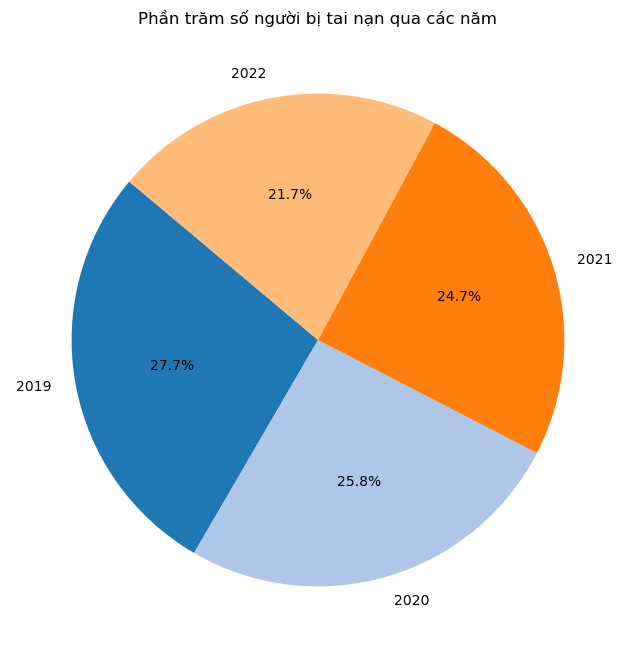

```python
# Chuyển đổi cột 'Accident Date' sang định dạng datetime và tạo cột 'Year'
df_cleaned['Year'] = pd.to_datetime(df_cleaned['Accident Date']).dt.year

# Nhóm dữ liệu theo năm và tính tổng số người bị tai nạn
yearly_casualties = df_cleaned.groupby('Year')['Number_of_Casualties'].sum()

# Tính phần trăm
percentages = (yearly_casualties / yearly_casualties.sum()) * 100

# Vẽ biểu đồ tròn
plt.figure(figsize=(10, 8))
plt.pie(
    percentages,
    labels=percentages.index,
    autopct='%1.1f%%',
    startangle=140,
    colors=plt.cm.tab20.colors
)

plt.title("Phần trăm số người bị tai nạn qua các năm")
plt.show()
```

#### Phân tích trung bình số lượng người bị tai nạn theo điều kiện thời tiết

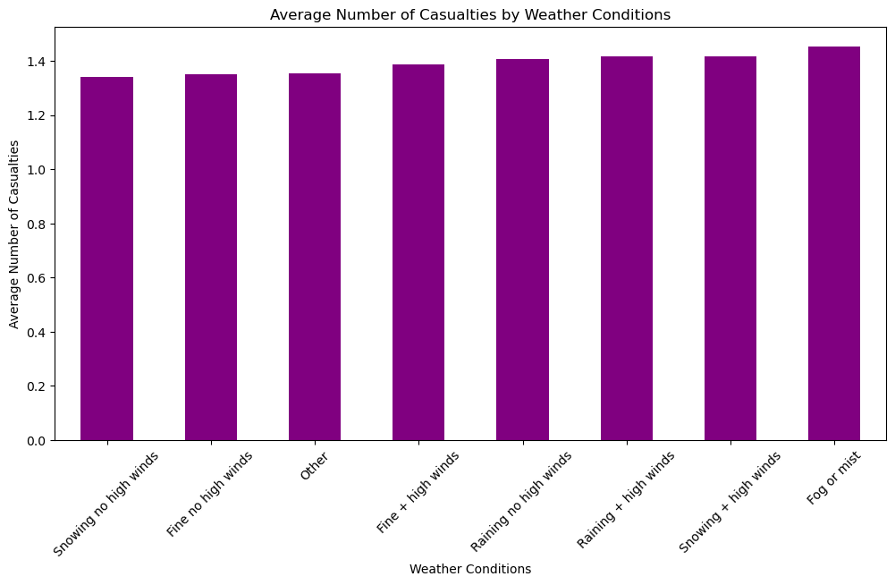

```python
# Nhóm dữ liệu theo điều kiện thời tiết và tính trung bình số người bị thương
weather_casualties = df.groupby('Weather_Conditions')['Number_of_Casualties'].mean()

# Vẽ biểu đồ
plt.figure(figsize=(12, 6))
weather_casualties.sort_values().plot(kind='bar', color='purple')
plt.title('Average Number of Casualties by Weather Conditions')
plt.xlabel('Weather Conditions')
plt.ylabel('Average Number of Casualties')
plt.xticks(rotation=45)
plt.show()
```

#### Phân tích số vụ tai nạn theo tháng và điều kiện thời tiết

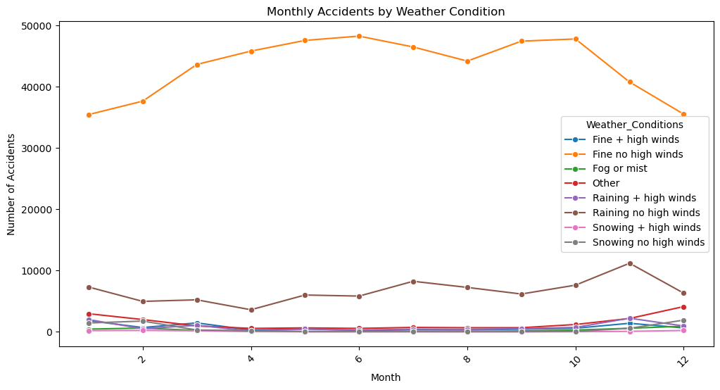

```python
# Tạo cột 'Month' từ ngày để phân tích theo thời gian
df['Month'] = pd.to_datetime(df['Accident Date']).dt.month

# Tính số vụ tai nạn theo điều kiện thời tiết và tháng
monthly_weather = df.groupby(['Month', 'Weather_Conditions']).size().unstack()

# Trực quan hóa Lineplot
plt.figure(figsize=(12,6))
sns.lineplot(data=monthly_weather, dashes=False, markers='o')
plt.title('Monthly Accidents by Weather Condition')
plt.xlabel('Month')
plt.ylabel('Number of Accidents')
plt.xticks(rotation=45)
plt.show()
```

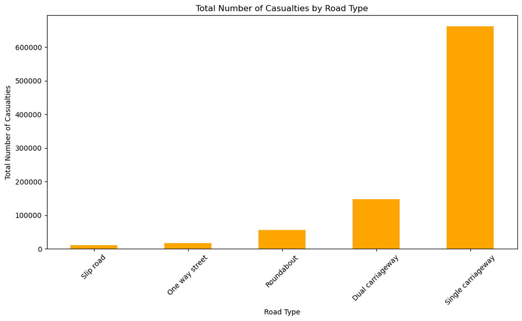

```python
# Nhóm dữ liệu theo loại đường và tính tổng số người bị thương
road_casualties = df.groupby('Road_Type')['Number_of_Casualties'].sum()

# Vẽ biểu đồ
plt.figure(figsize=(12, 6))
road_casualties.sort_values().plot(kind='bar', color='orange')
plt.title('Total Number of Casualties by Road Type')
plt.xlabel('Road Type')
plt.ylabel('Total Number of Casualties')
plt.xticks(rotation=45)
plt.show()
```

#### Phân tích sự tương quan giữa điều kiện thời tiết và loại đường

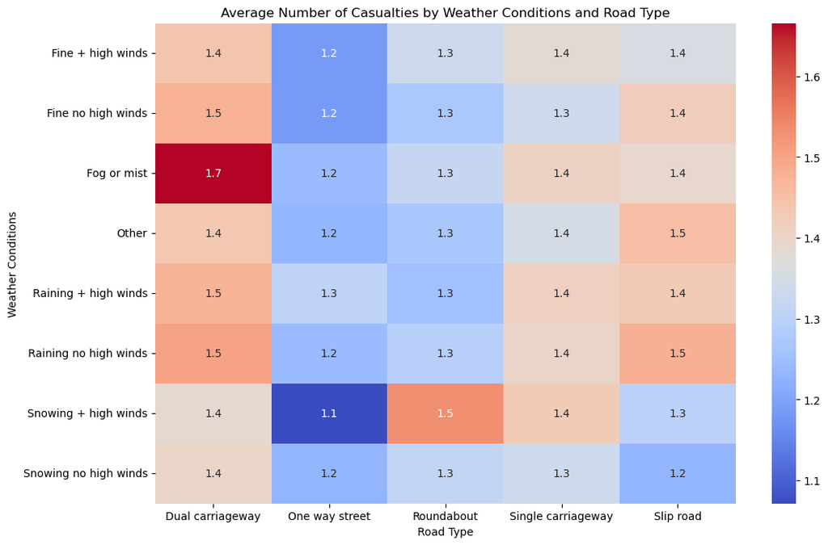

```python
# Tạo bảng pivot
pivot_table = df.pivot_table(
    values='Number_of_Casualties',
    index='Weather_Conditions',
    columns='Road_Type',
    aggfunc='mean'
)

# Vẽ heatmap
plt.figure(figsize=(12, 8))
sns.heatmap(pivot_table, annot=True, cmap='coolwarm', fmt='.1f')
plt.title('Average Number of Casualties by Weather Conditions and Road Type')
plt.xlabel('Road Type')
plt.ylabel('Weather Conditions')
plt.show()
```

#### Phân tích mối quan hệ giữa điều kiện thời tiết và mức độ nghiêm trọng của tai nạn.

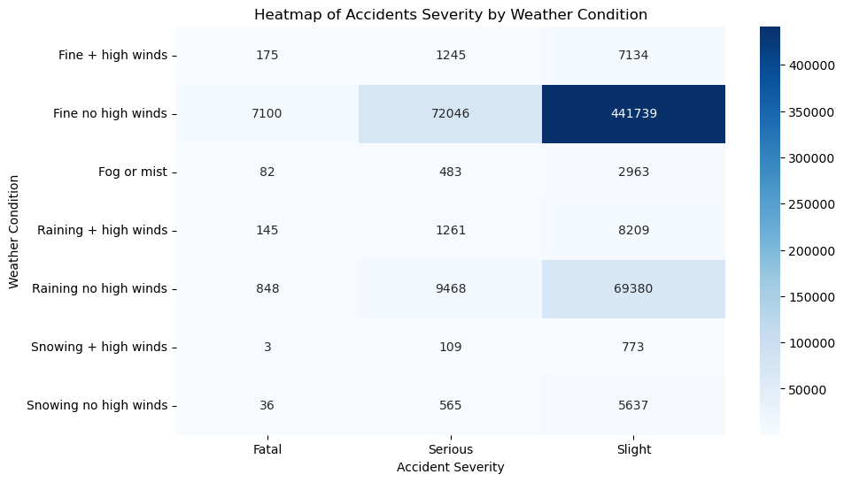

```python
import seaborn as sns
import matplotlib.pyplot as plt
# Tạo bảng dữ liệu cho Heatmap
severity_by_weather = df_cleaned.groupby(["Weather_Conditions", "Accident_Severity"]).size().unstack()

# Trực quan hóa Heatmap
plt.figure(figsize=(10,6))
sns.heatmap(severity_by_weather, annot=True, cmap='Blues', fmt='d')
plt.title('Heatmap of Accidents Severity by Weather Condition')
plt.xlabel('Accident Severity')
plt.ylabel('Weather Condition')
plt.show()
```

#### Phân tích tai nạn theo khu vực và ánh sáng

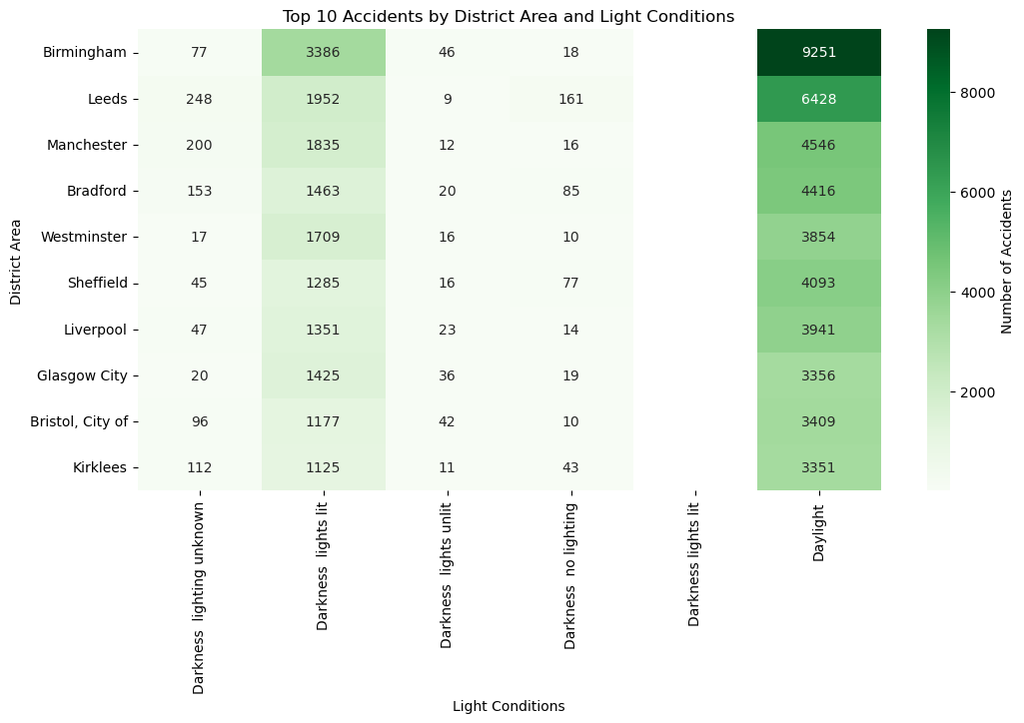

```python
import pandas as pd
import seaborn as sns
import matplotlib.pyplot as plt

# Tính số vụ tai nạn theo khu vực và điều kiện ánh sáng
accidents_by_light = df_cleaned.groupby(['District Area', 'Light_Conditions']).size().unstack()

# Chọn chỉ top 10 khu vực có số vụ tai nạn nhiều nhất
top_10_areas = accidents_by_light.sum(axis=1).nlargest(10).index
accidents_by_light_top10 = accidents_by_light.loc[top_10_areas]

# Trực quan hóa số vụ tai nạn theo khu vực và điều kiện ánh sáng (heatmap)
plt.figure(figsize=(12,6))
sns.heatmap(accidents_by_light_top10, annot=True, cmap='Greens', fmt='g', cbar_kws={'label': 'Number of Accidents'})
plt.title('Top 10 Accidents by District Area and Light Conditions')
plt.xlabel('Light Conditions')
plt.ylabel('District Area')
plt.show()
```

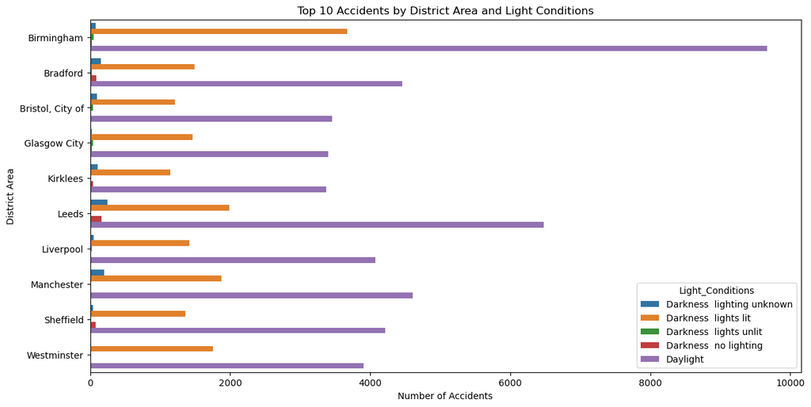

```python
# Tính số vụ tai nạn theo khu vực và điều kiện ánh sáng
accidents_by_light = df.groupby(['District Area', 'Light_Conditions']).size().reset_index(name='Accident Count')

# Chọn top 10 khu vực có số vụ tai nạn nhiều nhất
top_10_areas = accidents_by_light.groupby('District Area')['Accident Count'].sum().nlargest(10).index
accidents_by_light_top10 = accidents_by_light[accidents_by_light['District Area'].isin(top_10_areas)]

# Trực quan hóa số vụ tai nạn theo khu vực và điều kiện ánh sáng (barplot)
plt.figure(figsize=(14,7))
sns.barplot(x='Accident Count', y='District Area', hue='Light_Conditions', data=accidents_by_light_top10)
plt.title('Top 10 Accidents by District Area and Light Conditions')
plt.xlabel('Number of Accidents')
plt.ylabel('District Area')
plt.show()
```

#### Liệt kê 10 tiểu bang có nhiều tai nạn nhất để xác định đó là những tiểu bang nào.

```
District Area
Birmingham     12778
Leeds           8798
Manchester      6609
Bradford        6137
Westminster     5606
Name: count, dtype: int64
```

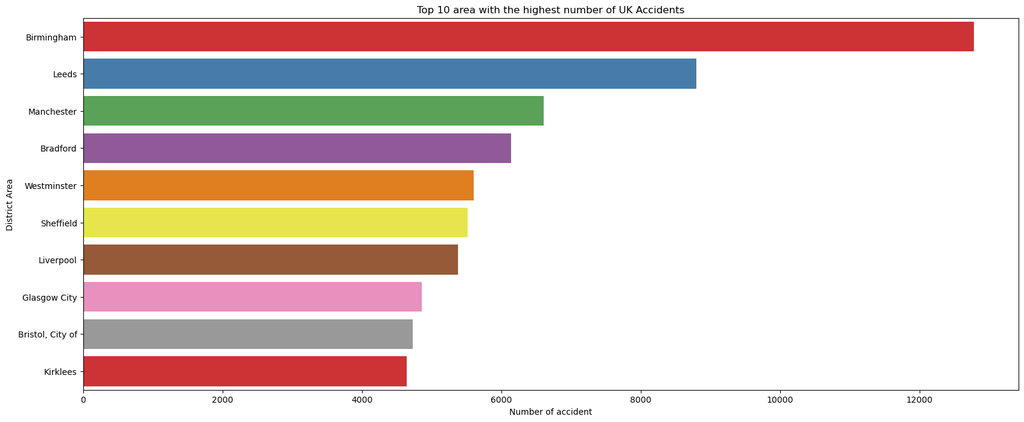

```python
import seaborn as sns
import matplotlib.pyplot as plt
import pandas as pd

# Giả sử bạn có một DataFrame `df` với cột 'District Area' và 'Accident ID'
# Đếm số vụ tai nạn theo khu vực
state_counts = df_cleaned['District Area'].value_counts()

# Tạo figure với kích thước lớn hơn
plt.figure(figsize=(20, 8))

# Kiểm tra dữ liệu trong state_counts
print(state_counts.head())

# Tiêu đề
plt.title("Top 10 area with the highest number of UK Accidents")

# Tạo barplot và gán palette để mỗi cột có một màu riêng
sns.barplot(x = state_counts[:10].values,
            y = state_counts[:10].index,
            orient="h",
            palette="Set1")

# Thêm nhãn
plt.xlabel("Number of accident")
plt.ylabel("District Area")

# Hiển thị đồ thị
plt.show()
```

#### Thống kê các vụ tai nạn qua các tháng theo từng năm

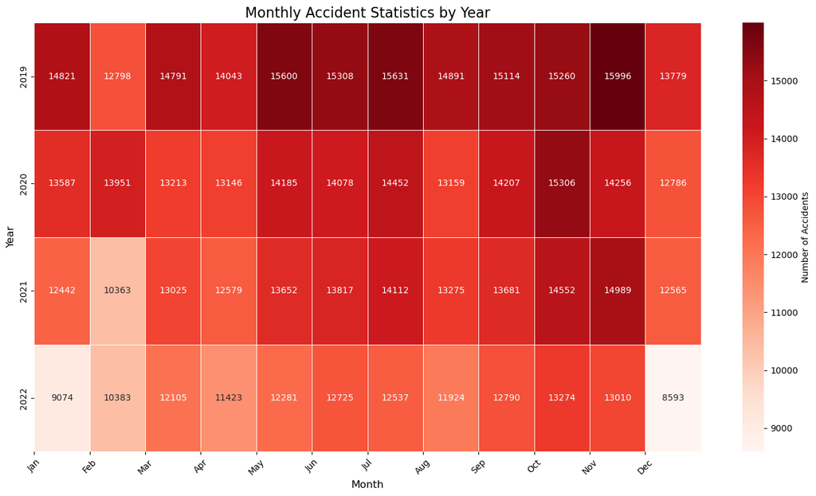

```python
import pandas as pd
import seaborn as sns
import matplotlib.pyplot as plt

# Giả sử `df_cleaned` là DataFrame đã được làm sạch và cột 'Accident Date' chứa thông tin ngày
# Đảm bảo cột 'Accident Date' ở dạng datetime
df_cleaned['Accident Date'] = pd.to_datetime(df_cleaned['Accident Date'])

# Thêm cột 'Year' và 'Month' từ cột 'Accident Date'
df_cleaned['Year'] = df_cleaned['Accident Date'].dt.year
df_cleaned['Month'] = df_cleaned['Accident Date'].dt.month

# Nhóm dữ liệu theo 'Year' và 'Month', đếm số vụ tai nạn
accidents_by_month_year = df_cleaned.groupby(['Year', 'Month']).size().unstack()

# Trực quan hóa dữ liệu
plt.figure(figsize=(14, 8))
sns.heatmap(
    accidents_by_month_year,
    annot=True,            # Hiển thị số vụ tai nạn trên heatmap
    cmap='Reds',          # Sử dụng bảng màu xanh lam
    fmt='g',               # Hiển thị số nguyên
    cbar_kws={'label': 'Number of Accidents'}, # Thêm nhãn cột màu
    linewidths=0.5         # Đường phân cách giữa các ô
)
plt.title('Monthly Accident Statistics by Year', fontsize=16)
plt.xlabel('Month', fontsize=12)
plt.ylabel('Year', fontsize=12)
plt.xticks(ticks=range(0, 12), labels=[
    'Jan', 'Feb', 'Mar', 'Apr', 'May', 'Jun',
    'Jul', 'Aug', 'Sep', 'Oct', 'Nov', 'Dec'
], rotation=45)
plt.tight_layout() # Điều chỉnh bố cục
plt.show()
```

#### Kiêm tra mối tương quan

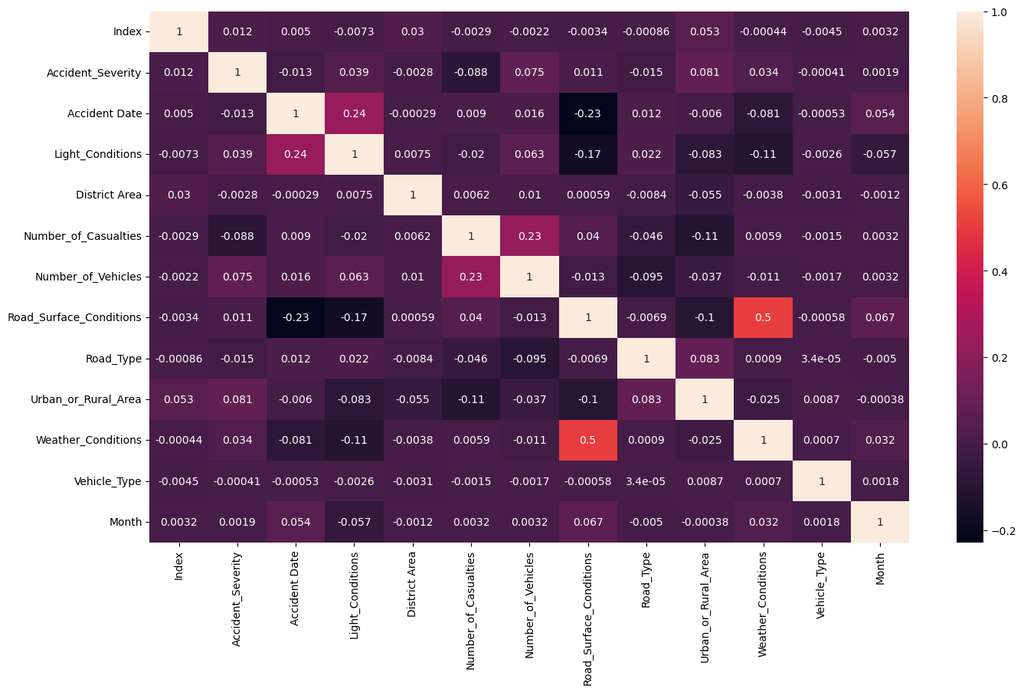

```python
from sklearn.preprocessing import LabelEncoder

# Chỉ mã hóa các cột có nhiều giá trị phân loại bằng Label Encoding
label_encoder = LabelEncoder()
for column in df.select_dtypes(include=['object']).columns:
    df[column] = label_encoder.fit_transform(df[column])

# Tính toán hệ số tương quan trên tập dữ liệu đã mã hóa
plt.figure(figsize=(16, 9))
sns.heatmap(df.corr(method='pearson'), annot=True)
plt.show()
```

#### Thống kê độ lệch giữa các thuộc tính của cột Accident_Severity

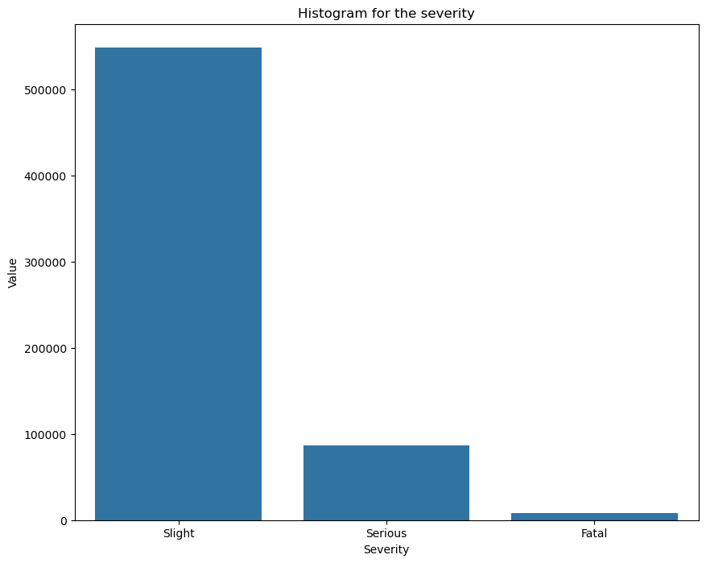

```python
# Vẽ biểu đồ phân phối các giá trị của Accident_Severity
severity_counts = df_cleaned['Accident_Severity'].value_counts()
plt.figure(figsize=(10, 8))
plt.title("Histogram for the severity")
sns.barplot(x=severity_counts.index, y=severity_counts.values)
plt.xlabel("Severity")
plt.ylabel("Value")
plt.show()
```

#### Cân bằng lại dữ liệu

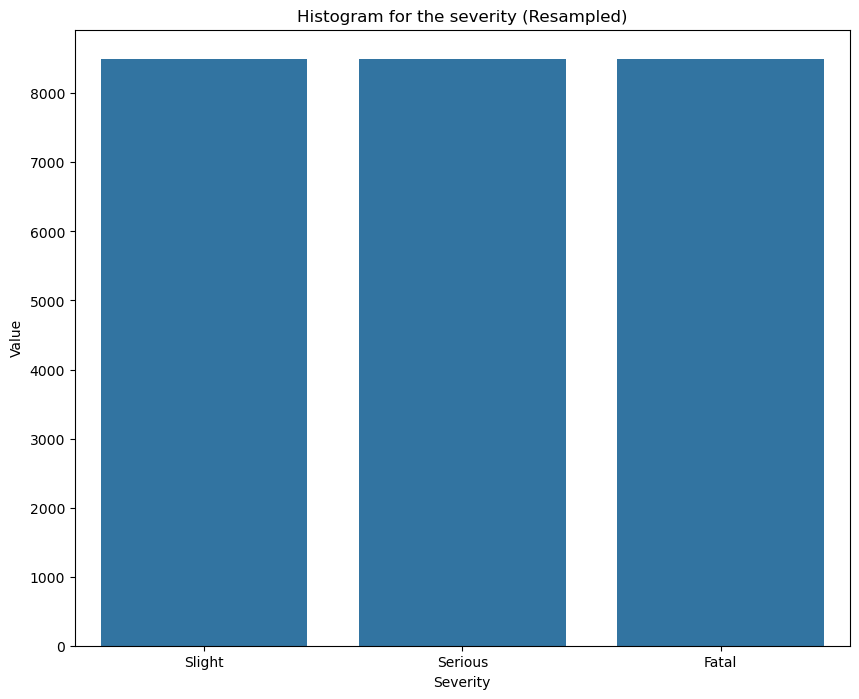

```python
# Lấy mẫu lại dữ liệu sao cho số lượng mẫu của các lớp là bằng nhau
severity_counts = df_cleaned['Accident_Severity'].value_counts()
min_size = severity_counts.min()
df_resampled = pd.DataFrame()

for i in severity_counts.index:
    S = df_cleaned[df_cleaned['Accident_Severity'] == i]
    # Nếu lớp có ít mẫu hơn min_size, lấy tất cả các mẫu, nếu không thì lấy mẫu ngẫu nhiên
    df_resampled = pd.concat([df_resampled, S.sample(min_size, random_state=42) if len(S) >= min_size else S], ignore_index=True)

# Hiển thị lại biểu đồ phân phối sau khi lấy mẫu lại
severity_counts_resampled = df_resampled['Accident_Severity'].value_counts()
plt.figure(figsize=(10, 8))
plt.title("Histogram for the severity (Resampled)")
sns.barplot(x=severity_counts_resampled.index, y=severity_counts_resampled.values)
plt.xlabel("Severity")
plt.ylabel("Value")
plt.show()
```

#### Tách các cột dữ liệu thành hai phần, một phần chứa các thuộc tính bình thường, một phần chứa riêng thuộc tính quyết định- Thuộc tính quyết định là Accident_Severity

```python
# Tách các tính năng và nhãn
features = ['Weather_Conditions', 'Road_Type', 'Light_Conditions', 'Road_Surface_Conditions']
label = 'Accident_Severity'
```

```python
# Xây dựng X (tính năng) và y (nhãn)
X = df_resampled[features]
y = df_resampled[label]
```

#### Mã hóa dữ liệu

```python
# Mã hóa các tính năng dạng chuỗi bằng LabelEncoder
le_features = {}
for column in X.select_dtypes(include=['object']).columns:
    le = LabelEncoder()
    X[column] = le.fit_transform(X[column])
    le_features[column] = le  # Lưu lại LabelEncoder để dùng khi cần mã hóa dữ liệu mới
```

```python
# Mã hóa nhãn
le_label = LabelEncoder()
y = le_label.fit_transform(y)
```

```python
# Xử lý dữ liệu, chuyển dummies cho các cột không phải số
df_resampled = df_resampled.drop(columns=['Index', 'Accident Date', 'Number_of_Casualties', 'Number_of_Vehicles'])
df_resampled = pd.get_dummies(df_resampled, columns=df_resampled.select_dtypes(include=['object']).columns, drop_first=False)
df_resampled = df_resampled.astype({col: 'int' for col in df_resampled.select_dtypes(include=['bool']).columns})
```

#### Tách các dòng dữ liệu ra thành hai phần huấn luyện và kiểm thử như ban đầu. Tiến hành tách dữ liệu huấn luyện và kiểm thử như thông tin thu được ban đầu.

```python
# Chia dữ liệu thành tập huấn luyện và kiểm tra
X_train, X_test, y_train, y_test = train_test_split(X, y, test_size=0.3, random_state=42)
```

#### RandomForestClassifier

```python
# RandomForestClassifier
rfc = RandomForestClassifier(n_jobs=-1, random_state=42)
```

```python
# Column transformer for OneHotEncoding
preprocessor = ColumnTransformer(
    transformers=[
        ('weather', OneHotEncoder(), ['Weather_Conditions'])
    ],
    remainder='passthrough'
)

# Tạo pipeline
pipeline = Pipeline(steps=[
    ('preprocessor', preprocessor),
    ('classifier', rfc)  # RandomForestClassifier
])

# Định nghĩa lưới tham số cho GridSearchCV
param_grid = {
    'classifier__max_depth': [10, 20, None],  # Các giá trị max_depth cần thử
    'classifier__n_estimators': [50, 100, 200],  # Các giá trị n_estimators cần thử
}

# Huấn luyện mô hình với GridSearchCV
grid = GridSearchCV(estimator=pipeline, param_grid=param_grid, n_jobs=-1, verbose=5)
grid.fit(X_train, y_train)

# Xuất ra các siêu tham số tốt nhất
print("Best parameters: ", grid.best_params_)

# Xuất điểm số độ chính xác trên dữ liệu huấn luyện và xác thực
print("Training accuracy: ", grid.score(X_train, y_train))
print("Test accuracy: ", grid.score(X_test, y_test))

# Tạo DataFrame chứa kết quả từ cross-validation
cv_results_df = pd.DataFrame(grid.cv_results_).sort_values(by="rank_test_score")
print(cv_results_df.head())
```

```
Fitting 5 folds for each of 9 candidates, totalling 45 fits
Best parameters:  {'classifier__max_depth': 10, 'classifier__n_estimators': 50}
Training accuracy:  0.4190908581357547
Test accuracy:  0.4064338956453511
   mean_fit_time  std_fit_time  mean_score_time  std_score_time  \
0       0.604352      0.306417         0.152196        0.084151
2       3.194671      0.565173         0.737038        0.414912
3       0.945314      0.226074         0.514748        0.245992
6       1.426023      0.299466         0.431801        0.055672
1       1.283089      0.134884         0.438073        0.075322

  param_classifier__max_depth  param_classifier__n_estimators  \
0                          10                              50
2                          10                             200
3                          20                              50
6                        None                              50
1                          10                             100

                                              params  split0_test_score  \
0  {'classifier__max_depth': 10, 'classifier__n_e...           0.404595
2  {'classifier__max_depth': 10, 'classifier__n_e...           0.402354
3  {'classifier__max_depth': 20, 'classifier__n_e...           0.401233
6  {'classifier__max_depth': None, 'classifier__n...           0.401233
1  {'classifier__max_depth': 10, 'classifier__n_e...           0.401513

   split1_test_score  split2_test_score  split3_test_score  split4_test_score  \
0           0.404428           0.408072           0.407791           0.397702
2           0.402747           0.407791           0.406110           0.399103
3           0.401906           0.409193           0.406390           0.398262
6           0.401906           0.409193           0.406390           0.398262
1           0.401626           0.406670           0.406110           0.399383

   mean_test_score  std_test_score  rank_test_score
0         0.404518        0.003737                1
2         0.403621        0.003045                2
3         0.403397        0.003894                3
6         0.403397        0.003894                3
1         0.403060        0.002839                5
```

```python
# Sử dụng mô hình RandomForest mặc định để so sánh
print("Default RandomForest scores:")
rfc.fit(X_train, y_train)
print("Training scores (default): ", rfc.score(X_train, y_train))
print("Test scores (default): ", rfc.score(X_test, y_test))
```

```
Default RandomForest scores:
Training scores (default):  0.41942716215458775
Test scores (default):  0.4053877337517981
```

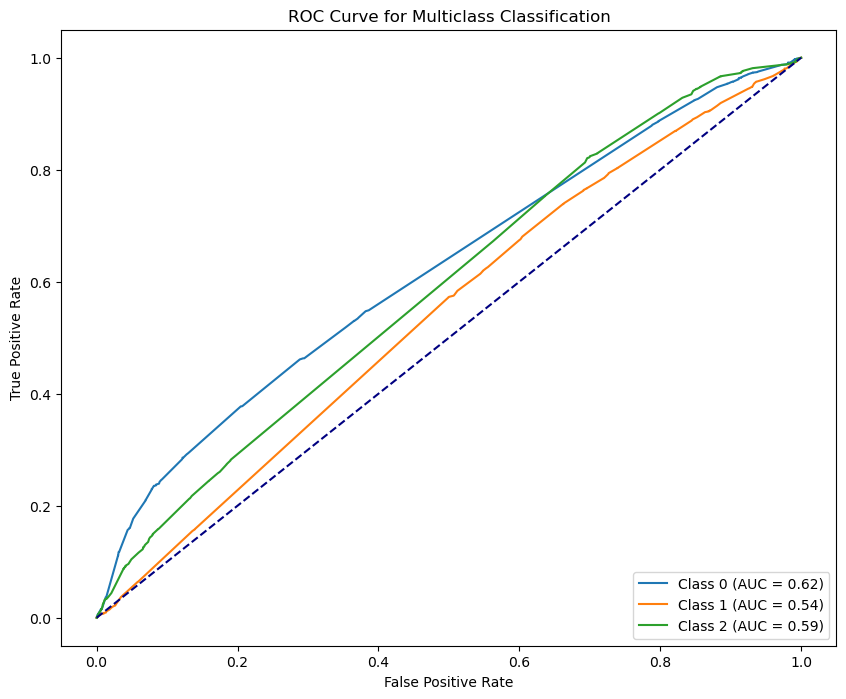

```python
from sklearn.metrics import roc_curve, auc
from sklearn.preprocessing import label_binarize
import matplotlib.pyplot as plt
from sklearn.metrics import roc_auc_score

# Binarize các nhãn lớp (chuyển các nhãn thành 0 và 1 cho mỗi lớp)
y_test_bin = label_binarize(y_test, classes=[0, 1, 2])  # Thay thế [0, 1, 2] bằng các lớp của bạn
n_classes = y_test_bin.shape[1]

# Dự đoán xác suất cho mỗi lớp
y_score = rfc.predict_proba(X_test)

# Vẽ ROC curve cho mỗi lớp
plt.figure(figsize=(10, 8))

for i in range(n_classes):
    fpr, tpr, thresholds = roc_curve(y_test_bin[:, i], y_score[:, i])
    roc_auc = auc(fpr, tpr)
    plt.plot(fpr, tpr, label=f'Class {i} (AUC = {roc_auc:.2f})')

# Thêm đường chéo thể hiện ngẫu nhiên
plt.plot([0, 1], [0, 1], color='navy', linestyle='--')

plt.title('ROC Curve for Multiclass Classification')
plt.xlabel('False Positive Rate')
plt.ylabel('True Positive Rate')
plt.legend(loc='lower right')
plt.show()
```

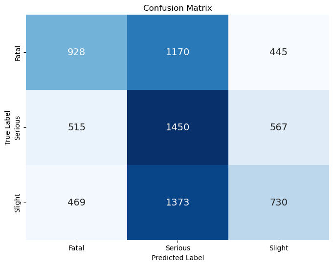

```python
from sklearn.metrics import confusion_matrix
import seaborn as sns
import matplotlib.pyplot as plt
import pandas as pd

# Dự đoán nhãn trên tập kiểm tra
y_pred = grid.predict(X_test)

# Tính ma trận nhầm lẫn
cm = confusion_matrix(y_test, y_pred)

# Chuyển ma trận nhầm lẫn thành DataFrame để dễ dàng trực quan hóa
cm_df = pd.DataFrame(cm, index=le_label.classes_, columns=le_label.classes_)

# Vẽ ma trận nhầm lẫn dưới dạng heatmap
plt.figure(figsize=(8, 6))
sns.heatmap(cm_df, annot=True, fmt='d', cmap='Blues', cbar=False, annot_kws={"size": 14})
plt.title("Confusion Matrix")
plt.xlabel("Predicted Label")
plt.ylabel("True Label")
plt.show()
```

```python
import pandas as pd

# Giả lập dữ liệu đầu vào mới
new_data = {
    'Weather_Conditions': ['Fine + high winds'],
    'Road_Type': ['Single carriageway'],
    'Light_Conditions': ['Daylight'],
    'Road_Surface_Conditions': ['Wet or damp'],
}

# Chuyển thành DataFrame
new_df = pd.DataFrame(new_data)

# Hiển thị dữ liệu mới
print(new_df)
```

```
  Weather_Conditions           Road_Type Light_Conditions  \
0  Fine + high winds  Single carriageway         Daylight

  Road_Surface_Conditions
0             Wet or damp
```

```python
# Mã hóa dữ liệu mới (sử dụng LabelEncoder hoặc OneHotEncoder)
for column in new_df.select_dtypes(include=['object']).columns:
    le = le_features[column]  # Dùng le_features đã lưu từ huấn luyện
    new_df[column] = le.transform(new_df[column])

# Dự đoán nhãn mới sử dụng mô hình đã huấn luyện
new_predictions = grid.predict(new_df)

# Chuyển kết quả dự đoán thành nhãn gốc
new_predictions_labels = le_label.inverse_transform(new_predictions)

# Hiển thị kết quả dự đoán
print("Predictions:", new_predictions_labels)
```

```
Predictions: ['Fatal']
```

```python
from sklearn import tree
clf = tree.DecisionTreeClassifier(criterion="entropy", random_state=0)
clf.fit(X_train, y_train)
```

```
DecisionTreeClassifier(criterion='entropy', random_state=0)
```

```python
from sklearn import metrics
# Đánh giá mô hình
y_pred = clf.predict(X_test)
print("Accuracy:", metrics.accuracy_score(y_test, y_pred))
print(metrics.classification_report(y_test, y_pred, target_names=le_label.classes_))
```

```
Accuracy: 0.4059108146985746
              precision    recall  f1-score   support

       Fatal       0.48      0.37      0.42      2543
     Serious       0.36      0.57      0.44      2532
      Slight       0.42      0.28      0.34      2572

    accuracy                           0.41      7647
   macro avg       0.42      0.41      0.40      7647
weighted avg       0.42      0.41      0.40      7647
```

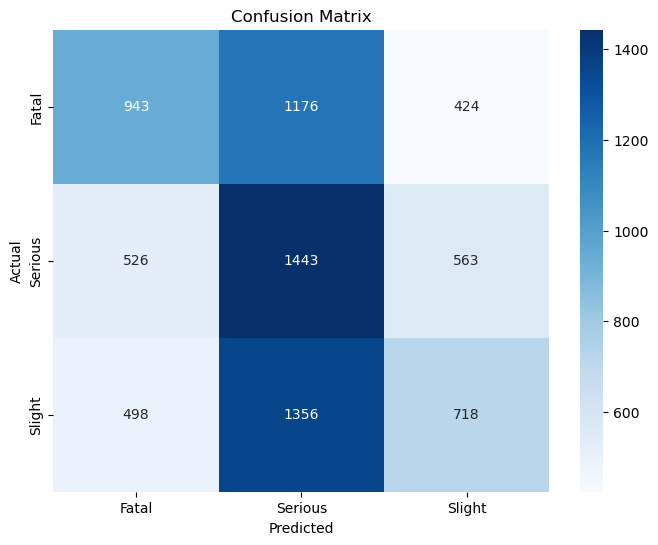

```python
cm = metrics.confusion_matrix(y_test, y_pred)
plt.figure(figsize=(8, 6))
sns.heatmap(cm, annot=True, fmt="d", cmap="Blues", xticklabels=le_label.classes_, yticklabels=le_label.classes_)
plt.ylabel('Actual')
plt.xlabel('Predicted')
plt.title("Confusion Matrix")
plt.show()
```

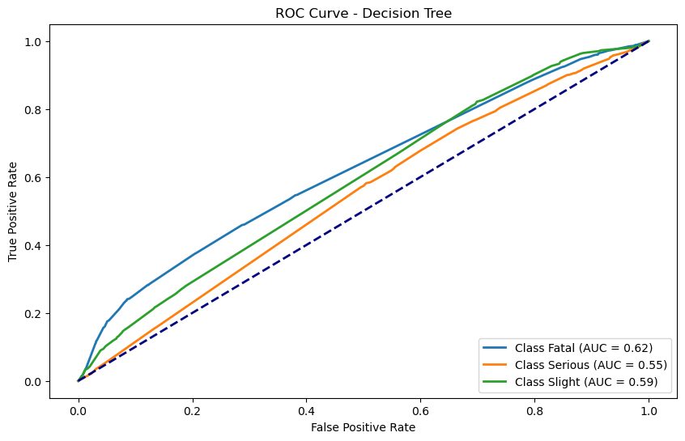

```python
from sklearn.metrics import roc_curve, auc
import numpy as np

# Nếu DecisionTree hỗ trợ `predict_proba`, tính xác suất dự đoán
y_pred_proba = clf.predict_proba(X_test)

# Tính ROC curve và AUC cho từng lớp
plt.figure(figsize=(10, 6))
for i, class_label in enumerate(le_label.classes_):
    fpr, tpr, _ = roc_curve(y_test == i, y_pred_proba[:, i])
    roc_auc = auc(fpr, tpr)
    plt.plot(fpr, tpr, lw=2, label=f'Class {class_label} (AUC = {roc_auc:.2f})')

# Thêm đường tham chiếu
plt.plot([0, 1], [0, 1], color="navy", lw=2, linestyle="--")
plt.xlabel("False Positive Rate")
plt.ylabel("True Positive Rate")
plt.title("ROC Curve - Decision Tree")
plt.legend(loc="lower right")
plt.show()
```

```python
def predict_severity(model, new_data, le_features, le_label, train_columns):
    """
    Dự đoán mức độ tai nạn dựa trên dữ liệu mới.

    Args:
        model: Mô hình đã huấn luyện.
        new_data: Dữ liệu mới (DataFrame).
        le_features: LabelEncoder cho các cột đặc trưng.
        le_label: LabelEncoder cho nhãn Accident_Severity.
        train_columns: Danh sách các cột đã được sử dụng để huấn luyện.

    Returns:
        predictions: Kết quả dự đoán ở dạng nhãn gốc.
    """
    # Thêm các cột thiếu với giá trị mặc định (ví dụ: 'unknown' hoặc '0')
    for col in train_columns:
        if col not in new_data.columns:
            new_data[col] = 'unknown' if col in le_features else 0

    # Sắp xếp lại thứ tự các cột
    new_data = new_data[train_columns]

    # Mã hóa dữ liệu mới
    for column in new_data.select_dtypes(include=['object']).columns:
        le = le_features[column]  # Sử dụng LabelEncoder tương ứng
        new_data[column] = le.transform(new_data[column])

    # Dự đoán
    predictions_encoded = model.predict(new_data)
    predictions = le_label.inverse_transform(predictions_encoded)  # Giải mã nhãn
    return predictions

# Danh sách các cột đã sử dụng để huấn luyện
train_columns = X_train.columns

# Ví dụ đầu vào
new_data = pd.DataFrame({
    'Weather_Conditions': ['Fine + high winds'],
    'Road_Type': ['Single carriageway'],
    'Light_Conditions': ['Daylight'],
    'Road_Surface_Conditions': ['Wet or damp'],
})

# Dự đoán
predicted_severity = predict_severity(clf, new_data, le_features, le_label, train_columns)
print("Dự đoán mức độ tai nạn:", predicted_severity)
```

```
Dự đoán mức độ tai nạn: ['Fatal']
```

#### LogisticRegression

```python
from sklearn.linear_model import LogisticRegression
model = LogisticRegression(random_state=42, max_iter=1000)
```

```python
model.fit(X_train, y_train)
```

```
LogisticRegression(max_iter=1000, random_state=42)
```

```python
from sklearn.ensemble import RandomForestClassifier
from sklearn.metrics import classification_report

y_pred = model.predict(X_test)
print("Accuracy:", metrics.accuracy_score(y_test, y_pred))
print(classification_report(y_test, y_pred))
```

```
Accuracy: 0.3733490257617366
              precision    recall  f1-score   support

           0       0.38      0.36      0.37      2543
           1       0.36      0.55      0.43      2532
           2       0.42      0.21      0.28      2572

    accuracy                           0.37      7647
   macro avg       0.38      0.37      0.36      7647
weighted avg       0.38      0.37      0.36      7647
```

```python
def predict_severity(model, new_data, le_features, le_label, train_columns):
    """
    Dự đoán mức độ tai nạn dựa trên dữ liệu mới.

    Args:
        model: Mô hình đã huấn luyện.
        new_data: Dữ liệu mới (DataFrame).
        le_features: LabelEncoder cho các cột đặc trưng.
        le_label: LabelEncoder cho nhãn Accident_Severity.
        train_columns: Danh sách các cột đã được sử dụng để huấn luyện.

    Returns:
        predictions: Kết quả dự đoán ở dạng nhãn gốc.
    """
    # Thêm các cột thiếu với giá trị mặc định (ví dụ: 'unknown' hoặc '0')
    for col in train_columns:
        if col not in new_data.columns:
            new_data[col] = 'unknown' if col in le_features else 0

    # Sắp xếp lại thứ tự các cột
    new_data = new_data[train_columns]

    # Mã hóa dữ liệu mới
    for column in new_data.select_dtypes(include=['object']).columns:
        # Kiểm tra xem LabelEncoder cho cột có tồn tại trong le_features không
        if column not in le_features:
            # Tạo mới LabelEncoder cho cột đó nếu chưa có
            le = LabelEncoder()
            le.fit(new_data[column])  # Huấn luyện LabelEncoder trên cột dữ liệu mới
            le_features[column] = le
        else:
            le = le_features[column]  # Sử dụng LabelEncoder đã có sẵn

        # Kiểm tra và thay thế giá trị 'unknown' trước khi mã hóa
        new_data[column] = new_data[column].apply(lambda x: x if x in le.classes_ else le.classes_[0])

        # Mã hóa giá trị cột đặc trưng
        new_data[column] = le.transform(new_data[column])

    # Dự đoán
    predictions_encoded = model.predict(new_data)
    predictions = le_label.inverse_transform(predictions_encoded)  # Giải mã nhãn
    return predictions

# Danh sách các cột đã sử dụng để huấn luyện
train_columns = X_train.columns

# Ví dụ đầu vào
new_data = pd.DataFrame({
    'Weather_Conditions': ['Fine + high winds'],
    'Road_Type': ['Single carriageway'],
    'Light_Conditions': ['Daylight'],
    'Road_Surface_Conditions': ['Wet or damp'],
})

# Dự đoán
predicted_severity = predict_severity(model, new_data, le_features, le_label, train_columns)
print("Dự đoán mức độ tai nạn:", predicted_severity)
```

```
Dự đoán mức độ tai nạn: ['Fatal']
```

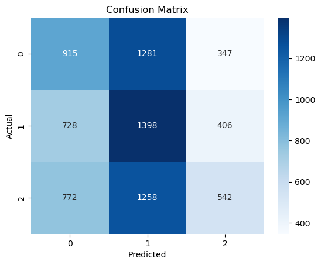

```python
from sklearn.metrics import confusion_matrix
import seaborn as sns
import matplotlib.pyplot as plt

cm = confusion_matrix(y_test, y_pred)
sns.heatmap(cm, annot=True, fmt='d', cmap='Blues')
plt.xlabel('Predicted')
plt.ylabel('Actual')
plt.title('Confusion Matrix')
plt.show()
```

#### GaussianNB

```python
from sklearn.naive_bayes import GaussianNB
from sklearn.metrics import accuracy_score, classification_report, confusion_matrix
import seaborn as sns
import matplotlib.pyplot as plt
```

```python
# Sử dụng Naïve Bayes (GaussianNB) để huấn luyện mô hình phân lớp trên tập train
nb_model = GaussianNB()
nb_model.fit(X_train, y_train)
```

```
GaussianNB()
```

```python
# Dự đoán nhãn lớp cho tập test
y_pred_nb = nb_model.predict(X_test)
```

```python
# Tính và in ra Accuracy của mô hình trên tập test
accuracy_nb = accuracy_score(y_test, y_pred_nb)
print(f"Accuracy của Naïve Bayes trên tập test: {accuracy_nb:.4f}")

# Tính và in ra Precision, Recall, F1-score của từng lớp và trung bình của mô hình trên tập test
print("\nPrecision, Recall, F1-score cho Naïve Bayes:")
print(classification_report(y_test, y_pred_nb))
```

```
Accuracy của Naïve Bayes trên tập test: 0.3698

Precision, Recall, F1-score cho Naïve Bayes:
              precision    recall  f1-score   support

           0       0.40      0.29      0.33      2543
           1       0.35      0.66      0.46      2532
           2       0.40      0.17      0.24      2572

    accuracy                           0.37      7647
   macro avg       0.38      0.37      0.34      7647
weighted avg       0.38      0.37      0.34      7647
```

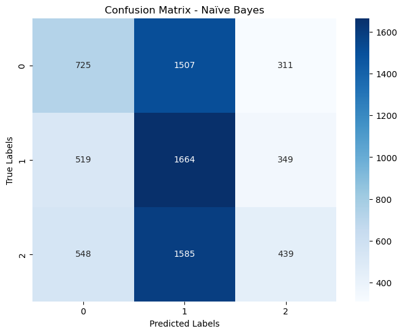

```python
# Tính và hiển thị Confusion Matrix cho Naïve Bayes
cm_nb = confusion_matrix(y_test, y_pred_nb)
plt.figure(figsize=(8, 6))
sns.heatmap(cm_nb, annot=True, fmt='d', cmap='Blues')
plt.title("Confusion Matrix - Naïve Bayes")
plt.xlabel("Predicted Labels")
plt.ylabel("True Labels")
plt.show()
```

```python
def predict_severity(model, new_data, le_features, le_label, train_columns):
    """
    Dự đoán mức độ tai nạn dựa trên dữ liệu mới.

    Args:
        model: Mô hình đã huấn luyện.
        new_data: Dữ liệu mới (DataFrame).
        le_features: LabelEncoder cho các cột đặc trưng.
        le_label: LabelEncoder cho nhãn Accident_Severity.
        train_columns: Danh sách các cột đã được sử dụng để huấn luyện.

    Returns:
        predictions: Kết quả dự đoán ở dạng nhãn gốc.
    """
    # Thêm các cột thiếu với giá trị mặc định (ví dụ: 'unknown' hoặc '0')
    for col in train_columns:
        if col not in new_data.columns:
            new_data[col] = 'unknown' if col in le_features else 0

    # Sắp xếp lại thứ tự các cột
    new_data = new_data[train_columns]

    # Mã hóa dữ liệu mới
    for column in new_data.select_dtypes(include=['object']).columns:
        # Kiểm tra xem LabelEncoder cho cột có tồn tại trong le_features không
        if column not in le_features:
            # Tạo mới LabelEncoder cho cột đó nếu chưa có
            le = LabelEncoder()
            le.fit(new_data[column])  # Huấn luyện LabelEncoder trên cột dữ liệu mới
            le_features[column] = le
        else:
            le = le_features[column]  # Sử dụng LabelEncoder đã có sẵn

        # Kiểm tra và thay thế giá trị 'unknown' trước khi mã hóa
        new_data[column] = new_data[column].apply(lambda x: x if x in le.classes_ else le.classes_[0])

        # Mã hóa giá trị cột đặc trưng
        new_data[column] = le.transform(new_data[column])

    # Dự đoán
    predictions_encoded = model.predict(new_data)
    predictions = le_label.inverse_transform(predictions_encoded)  # Giải mã nhãn
    return predictions

# Danh sách các cột đã sử dụng để huấn luyện
train_columns = X_train.columns

# Ví dụ đầu vào
new_data = pd.DataFrame({
    'Weather_Conditions': ['Fine + high winds'],
    'Road_Type': ['Single carriageway'],
    'Light_Conditions': ['Daylight'],
    'Road_Surface_Conditions': ['Wet or damp'],
})

# Dự đoán
predicted_severity = predict_severity(nb_model, new_data, le_features, le_label, train_columns)
print("Dự đoán mức độ tai nạn:", predicted_severity)
```

```
Dự đoán mức độ tai nạn: ['Slight']
```

#### KNeighborsClassifier

```python
from sklearn.neighbors import KNeighborsClassifier
```

```python
# Sử dụng KNN để huấn luyện mô hình phân lớp trên tập train
knn_model = KNeighborsClassifier(n_neighbors=3)  # Sử dụng k=3, có thể thay đổi tùy chọn
knn_model.fit(X_train, y_train)

# Dự đoán nhãn lớp cho tập test
y_pred_knn = knn_model.predict(X_test)
```

```python
# Tính và in ra Accuracy của mô hình trên tập test
accuracy_knn = accuracy_score(y_test, y_pred_knn)
print(f"Accuracy của KNN trên tập test: {accuracy_knn:.4f}")

# Tính và in ra Precision, Recall, F1-score của từng lớp và trung bình của mô hình trên tập test
print("\nPrecision, Recall, F1-score cho KNN:")
print(classification_report(y_test, y_pred_knn))
```

```
Accuracy của KNN trên tập test: 0.3732

Precision, Recall, F1-score cho KNN:
              precision    recall  f1-score   support

           0       0.42      0.26      0.32      2543
           1       0.33      0.19      0.24      2532
           2       0.37      0.67      0.48      2572

    accuracy                           0.37      7647
   macro avg       0.37      0.37      0.35      7647
weighted avg       0.37      0.37      0.35      7647
```

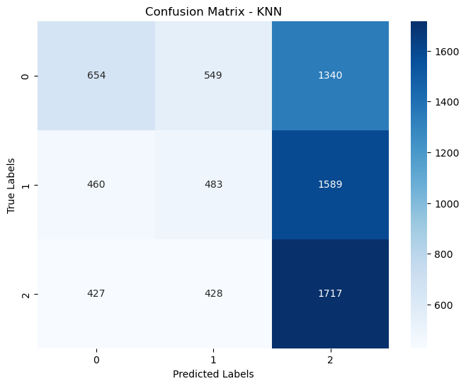

```python
# Tính và hiển thị Confusion Matrix cho KNN
cm_knn = confusion_matrix(y_test, y_pred_knn)
plt.figure(figsize=(8, 6))
sns.heatmap(cm_knn, annot=True, fmt='d', cmap='Blues')
plt.title("Confusion Matrix - KNN")
plt.xlabel("Predicted Labels")
plt.ylabel("True Labels")
plt.show()
```

```python
def predict_severity(model, new_data, le_features, le_label, train_columns):
    """
    Dự đoán mức độ tai nạn dựa trên dữ liệu mới.

    Args:
        model: Mô hình đã huấn luyện.
        new_data: Dữ liệu mới (DataFrame).
        le_features: LabelEncoder cho các cột đặc trưng.
        le_label: LabelEncoder cho nhãn Accident_Severity.
        train_columns: Danh sách các cột đã được sử dụng để huấn luyện.

    Returns:
        predictions: Kết quả dự đoán ở dạng nhãn gốc.
    """
    # Thêm các cột thiếu với giá trị mặc định (ví dụ: 'unknown' hoặc '0')
    for col in train_columns:
        if col not in new_data.columns:
            new_data[col] = 'unknown' if col in le_features else 0

    # Sắp xếp lại thứ tự các cột
    new_data = new_data[train_columns]

    # Mã hóa dữ liệu mới
    for column in new_data.select_dtypes(include=['object']).columns:
        # Kiểm tra xem LabelEncoder cho cột có tồn tại trong le_features không
        if column not in le_features:
            # Tạo mới LabelEncoder cho cột đó nếu chưa có
            le = LabelEncoder()
            le.fit(new_data[column])  # Huấn luyện LabelEncoder trên cột dữ liệu mới
            le_features[column] = le
        else:
            le = le_features[column]  # Sử dụng LabelEncoder đã có sẵn

        # Kiểm tra và thay thế giá trị 'unknown' trước khi mã hóa
        new_data[column] = new_data[column].apply(lambda x: x if x in le.classes_ else le.classes_[0])

        # Mã hóa giá trị cột đặc trưng
        new_data[column] = le.transform(new_data[column])

    # Dự đoán
    predictions_encoded = model.predict(new_data)
    predictions = le_label.inverse_transform(predictions_encoded)  # Giải mã nhãn
    return predictions

# Danh sách các cột đã sử dụng để huấn luyện
train_columns = X_train.columns

# Ví dụ đầu vào
new_data = pd.DataFrame({
    'Weather_Conditions': ['Fine + high winds'],
    'Road_Type': ['Single carriageway'],
    'Light_Conditions': ['Daylight'],
    'Road_Surface_Conditions': ['Wet or damp'],
})

# Dự đoán
predicted_severity = predict_severity(knn_model, new_data, le_features, le_label, train_columns)
print("Dự đoán mức độ tai nạn:", predicted_severity)
```

```
Dự đoán mức độ tai nạn: ['Slight']
```